# Predicting Stock Prices and Asset Bubbles Using Deep Learning: A Case Study of Nvidia

## Deep Learning Models

### Preparing for modeling with deep learning

```python
print(historical_data.columns)
```

```
Index(['Open', 'High', 'Low', 'Close', 'Adj Close', 'Volume'], dtype='object')
```

```python
historical_data
```

| Date | Open | High | Low | Close | Adj Close | Volume |
| --- | --- | --- | --- | --- | --- | --- |
| 1999-01-22 | 0.043750 | 0.048828 | 0.038802 | 0.041016 | 0.037621 | 2714688000 |
| 1999-01-25 | 0.044271 | 0.045833 | 0.041016 | 0.045313 | 0.041562 | 510480000 |
| 1999-01-26 | 0.045833 | 0.046745 | 0.041146 | 0.041797 | 0.038337 | 343200000 |
| 1999-01-27 | 0.041927 | 0.042969 | 0.039583 | 0.041667 | 0.038218 | 244368000 |
| 1999-01-28 | 0.041667 | 0.041927 | 0.041276 | 0.041536 | 0.038098 | 227520000 |
| ... | ... | ... | ... | ... | ... | ... |
| 2024-08-19 | 124.279999 | 130.000000 | 123.419998 | 130.000000 | 130.000000 | 318333600 |
| 2024-08-20 | 128.399994 | 129.880005 | 125.889999 | 127.250000 | 127.250000 | 300087400 |
| 2024-08-21 | 127.320000 | 129.350006 | 126.660004 | 128.500000 | 128.500000 | 257883600 |
| 2024-08-22 | 130.020004 | 130.750000 | 123.099998 | 123.739998 | 123.739998 | 376189100 |
| 2024-08-23 | 125.860001 | 129.600006 | 125.220001 | 129.369995 | 129.369995 | 322154200 |

6439 rows × 6 columns

```python
historical_data['Date'] = pd.to_datetime(historical_data['Date'])

# Extract the month and year from the 'Date' column
historical_data['Month'] = historical_data['Date'].dt.month
historical_data['Year'] = historical_data['Date'].dt.year


# Calculate the mean close price per month
monthly_mean = historical_data.groupby([ 'Month'])['Close'].mean().reset_index()

# Calculate the mean close price per year
yearly_mean = historical_data.groupby([ 'Year'])['Close'].mean().reset_index()
```

```python
monthly_mean
```

|  | Month | Close |
| --- | --- | --- |
| 0 | 1 | 5.522396 |
| 1 | 2 | 6.457112 |
| 2 | 3 | 6.915237 |
| 3 | 4 | 7.174047 |
| 4 | 5 | 7.657969 |
| 5 | 6 | 8.710696 |
| 6 | 7 | 9.452513 |
| 7 | 8 | 8.354578 |
| 8 | 9 | 4.830454 |
| 9 | 10 | 4.725578 |
| 10 | 11 | 5.492252 |
| 11 | 12 | 5.395396 |

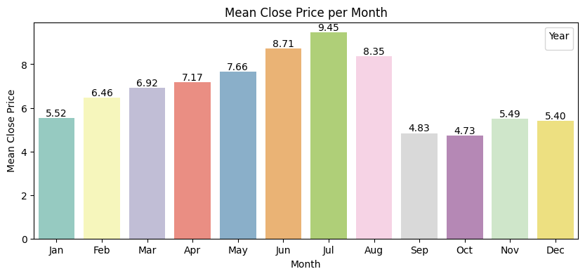

```python
# Plot the mean close price per month using a Seaborn bar chart
ax =sns.barplot(data=monthly_mean, x='Month', y='Close',  palette='Set3')

plt.title('Mean Close Price per Month')
plt.xlabel('Month')
plt.ylabel('Mean Close Price')

plt.xticks(range(0, 12), labels=['Jan', 'Feb', 'Mar', 'Apr', 'May', 'Jun', 'Jul', 'Aug', 'Sep', 'Oct', 'Nov', 'Dec'])
plt.legend(title='Year')

for bars in ax.containers:
     ax.bar_label(bars, fontsize=10, fmt='%.2f')
plt.show()
```

The Mean Close Price per Month in the first eight months is generally higher than that in the last four months.

```python
yearly_mean.head()
```

[output not shown]

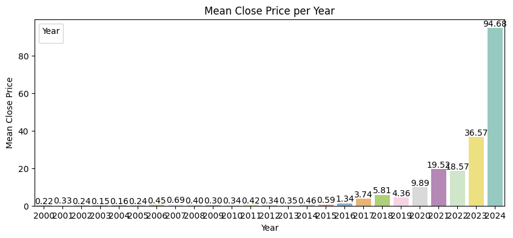

```python
lst_year= yearly_mean['Year'].tolist()

# Plot the mean close price per month using a Seaborn bar chart
ax = sns.barplot(data=yearly_mean, x='Year', y='Close',  palette='Set3')

plt.title('Mean Close Price per Year')
plt.xlabel('Year')
plt.ylabel('Mean Close Price')

plt.xticks(range(0, len(lst_year)), labels=lst_year)
plt.legend(title='Year')

for bars in ax.containers:
     ax.bar_label(bars, fontsize=10, fmt='%.2f')

plt.show()
```

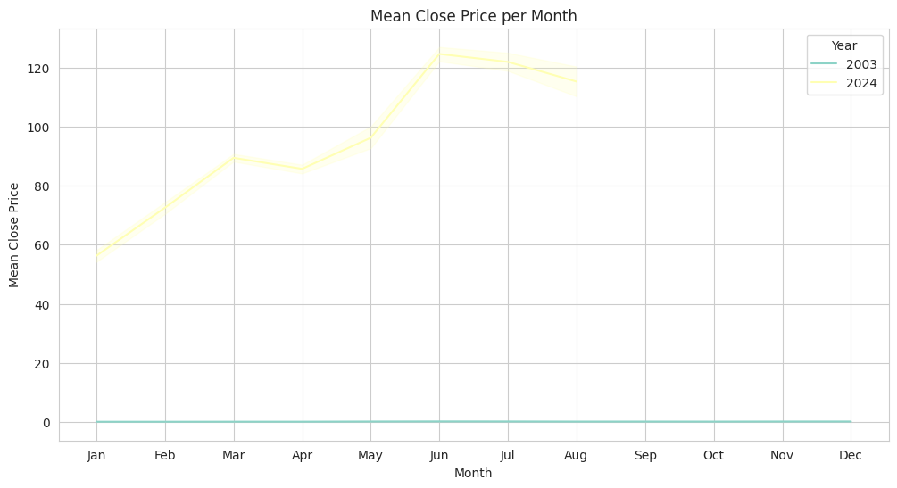

```python
# Plot the mean close price per month using a Seaborn bar chart
plt.figure(figsize=(12, 6))

filtered_df = historical_data[historical_data['Year'].isin([2003,2024])]
sns.lineplot(data=filtered_df, x='Month', y='Close', hue='Year', palette='Set3')

plt.title('Mean Close Price per Month')

plt.xlabel('Month')
plt.ylabel('Mean Close Price')

plt.xticks(range(1, 13), labels=['Jan', 'Feb', 'Mar', 'Apr', 'May', 'Jun', 'Jul', 'Aug', 'Sep', 'Oct', 'Nov', 'Dec'])

plt.legend(title='Year')
plt.show()
```

With our target being Closing price (USD), it is reasonable to assume that there may be some seasonality in our target.

We know that capture information from the previous seasonal cycle can help us forecast our time series. Therefore, it is important to determine ways to identify seasonality in time series. Usually, plotting the time series data is enough to observe periodic patterns.

We can plot our target to see if we can visually detect any seasonality.

Yearly Seasonality

yearly cyclic behavior refers to a repeating pattern or trend that occurs within each year, the absence of it indicates that there is no noticeable pattern or trend that repeats on an annual basis. This suggests that the stock market data does not exhibit consistent fluctuations or variations that occur predictably from one year to the next. There may be other factors or irregularities at play that overshadow any yearly cyclic behavior.

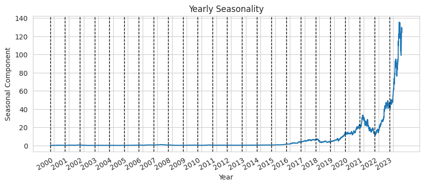

```python
fig, ax = plt.subplots()

ax.plot(historical_data['Close'])
for i in np.arange(0, len(historical_data), 260):
    ax.axvline(x=i, linestyle='--', color='black', linewidth=1)

plt.title('Yearly Seasonality')
plt.xlabel('Year')
plt.ylabel('Seasonal Component')

plt.xticks(np.arange(67, len(historical_data), 260), np.arange(2000, 2024, 1))

plt.figure(figsize=(10, 5))

fig.autofmt_xdate()
plt.tight_layout()
```

Highlighting the seasonal pattern in the Yearly Close Price. The dashed vertical lines separate periods of 260 working days per year.

We can clearly see the yearly frequency does not show any cyclic behavior. Therefore, there is no yearly seasonality

Another way of identifying seasonal patterns in a time series is using time series decomposition,We can decompose the dataset for Stock Prices using the tsa.seasonal_decompose function from the statsmodels library

Monthly Seasonality

Monthly cyclic behavior refers to a repeating pattern or trend that occurs within each month. It suggests that there are consistent fluctuations or variations in the stock market data that repeat on a monthly basis. This could be due to various factors, such as economic events, market sentiment, or trading patterns that occur within specific months.

[figure not shown]

```python
df_seasonality = historical_data.copy()

# Set 'Date' column as the index of the DataFrame
df_seasonality.set_index('Date', inplace=True)

# Resample the data to monthly frequency
monthly_data = df_seasonality['Close'].resample('M').mean()

# Get the month numbers for the xticks
month_numbers = pd.to_datetime(monthly_data.index).strftime('%m')

df_monthly_data= monthly_data.to_frame(name="Close")
df_monthly_data['month_numbers'] = month_numbers

# Perform seasonal decomposition
decomposition = sm.tsa.seasonal_decompose(monthly_data, model='additive')

# Plot the seasonal component
fig, ax = plt.subplots()

decomposition.seasonal.plot(ax=ax)

times = np.arange('2000-01', '2024-08', dtype='datetime64[M]')
ax.set_xticks(times)
# ax.set_xticklabels(times )

for i in np.arange(0, len(historical_data), 1):
    ax.axvline(x=i, linestyle='--', color='black', linewidth=1)

plt.title('Monthly Seasonality' ,  fontsize = 12)
plt.xlabel('Month',  fontsize = 10)
plt.ylabel('Seasonal Component',fontsize = 10)

plt.rcParams['figure.figsize'] = (30, 10)

fig.autofmt_xdate()
ax.set_xticklabels(times,rotation = 75,
                   ha = 'right', fontsize = 12,
                   color = 'blue')

plt.tight_layout()
plt.show()
```

We can see that in our stock market data, recurring patterns indicate monthly seasonality. The dashed vertical lines separate the one-month periods for each year.

This observation is often enough to determine that a data set is seasonal and indicates that there is a monthly pattern or seasonality in the data.

According to tradethatswing, these are the best and worst months for the stock market - seasonal patterns

```python
# 'Month','Year',
cols_to_drop = ['Date']
historical_data = historical_data.drop(cols_to_drop, axis=1)

historical_data.head()
```

|  | Open | High | Low | Close | Adj Close | Volume | Month | Year |
| --- | --- | --- | --- | --- | --- | --- | --- | --- |
| 0 | 0.098438 | 0.099219 | 0.091927 | 0.097526 | 0.089453 | 300912000 | 1 | 2000 |
| 1 | 0.095833 | 0.096094 | 0.090104 | 0.094922 | 0.087065 | 300480000 | 1 | 2000 |
| 2 | 0.092188 | 0.093750 | 0.090495 | 0.091797 | 0.084199 | 188352000 | 1 | 2000 |
| 3 | 0.091797 | 0.091797 | 0.082292 | 0.085807 | 0.078704 | 120480000 | 1 | 2000 |
| 4 | 0.085417 | 0.088151 | 0.084115 | 0.087240 | 0.080019 | 71184000 | 1 | 2000 |

```python
# Splitting and scaling the data
n = len(historical_data)

# Split 70:20:10 (train:validation:test)
train_df = historical_data[0:int(n*0.7)]
val_df = historical_data[int(n*0.7):int(n*0.9)]
test_df = historical_data[int(n*0.9):]
```

```python
from sklearn.preprocessing import MinMaxScaler

scaler = MinMaxScaler()
scaler.fit(train_df)

train_df[train_df.columns] = scaler.transform(train_df[train_df.columns])
val_df[val_df.columns] = scaler.transform(val_df[val_df.columns])
test_df[test_df.columns] = scaler.transform(test_df[test_df.columns])
```

```python
train_df.to_csv('../train.csv', index=False, header=True)
val_df.to_csv('../val.csv', index=False, header=True)
test_df.to_csv('../test.csv', index=False, header=True)
```

```python
column_indices = {name: i for i, name in enumerate(train_df.columns)}
```

### No Sentiment Data Denoising Modeling with Deep Learning

DataWindow class allows us to quickly create windows of data for training deep learning models. Each window of data contains a set of inputs and a set of labels. The model is then trained to produce predictions as close as possible to the labels using the inputs.time windows

```python
class DataWindow():

  def __init__(self, input_width, label_width, shift,
                 train_df=train_df, val_df=val_df, test_df=test_df,
                 label_columns=None):

            self.train_df = train_df
            self.val_df = val_df
            self.test_df = test_df

            #Name of the column that we wish to predict
            self.label_columns = label_columns
            if label_columns is not None:
                #Create a dictionary with the name and index of the label column. This will be used for plotting.
                self.label_columns_indices = {name: i for i, name in enumerate(label_columns)}
            #Create a dictionary with the name and index of each column. This will be used to separate the features from the target variable
            self.column_indices = {name: i for i, name in enumerate(train_df.columns)}

            self.input_width = input_width
            self.label_width = label_width
            self.shift = shift

            self.total_window_size = input_width + shift

            #The slice function returns a slice object that specifies how to slice a sequence.
            # In this case, it says that the input slice starts at 0 and ends when we reach the input_width.
            self.input_slice = slice(0, input_width)
            #Assign indices to the inputs. These are useful for plotting.
            self.input_indices = np.arange(self.total_window_size)[self.input_slice]


            #Get the index at which the label starts. In this case, it is the total window size minus the width of the label.
            self.label_start = self.total_window_size - self.label_width
            #The same steps that were applied for the inputs are applied for labels.
            self.labels_slice = slice(self.label_start, None)
            self.label_indices = np.arange(self.total_window_size)[self.labels_slice]

  def split_to_inputs_labels(self, features):
            #Slice the window to get the inputs using the input_slice defined in __init__.
            inputs = features[:, self.input_slice, :]
            #Slice the window to get the labels using the labels_slice defined in __init__
            labels = features[:, self.labels_slice, :]

            #If we have more than one target, we stack the labels.
            if self.label_columns is not None:
                labels = tf.stack(
                    [labels[:,:,self.column_indices[name]] for name in self.label_columns],
                    axis=-1
                )
            #The shape will be [batch, time, features].
            # At this point,we only specify the time dimension and allow the batch and feature dimensions to be defined later.
            inputs.set_shape([None, self.input_width, None])
            labels.set_shape([None, self.label_width, None])

            return inputs, labels

  def plot(self, model=None, plot_col='Close', max_subplots=3):
            inputs, labels = self.sample_batch

            plt.figure(figsize=(12, 8))
            plot_col_index = self.column_indices[plot_col]
            max_n = min(max_subplots, len(inputs))

            #Plot the inputs. They will  appear as a continuous blue line with dots.
            for n in range(max_n):
                plt.subplot(3, 1, n+1)
                plt.ylabel(f'{plot_col} [scaled]')
                plt.plot(self.input_indices, inputs[n, :, plot_col_index],
                        label='Inputs', marker='.', zorder=-10)

                if self.label_columns:
                  label_col_index = self.label_columns_indices.get(plot_col, None)
                else:
                  label_col_index = plot_col_index

                if label_col_index is None:
                  continue

                #Plot the labels or actual. They will appear as green squares.
                plt.scatter(self.label_indices, labels[n, :, label_col_index],
                            edgecolors='k', marker='s', label='Labels', c='green', s=64)
                if model is not None:
                  predictions = model(inputs)
                  #Plot the predictions. They will appear as red crosses.
                  plt.scatter(self.label_indices, predictions[n, :, label_col_index],
                              marker='X', edgecolors='k', label='Predictions',
                              c='red', s=64)

                if n == 0:
                  plt.legend()

            plt.xlabel('Date (Day)')
            plt.ylabel('Closing price (USD)')

  def make_dataset(self, data):
            data = np.array(data, dtype=np.float32)
            ds = tf.keras.preprocessing.timeseries_dataset_from_array(
                #Pass in the data. This corresponds to our training set, validation set, or test set.
                data=data,
                #Targets are set to None, as they are handled by the split_to_input_labels function.
                targets=None,
                #Define the total length of s the array, which is equal to the total window length.
                sequence_length=self.total_window_size,
                #Define the number of timesteps separating each sequence. In our case, we want the sequences to be consecutive, so sequence_stride=1.
                sequence_stride=1,
                #Shuffle the sequences. Keep in mind that the data is still in chronological order. We are simply shuffling the order of the sequences, which makes the model more robus
                shuffle=True,
                #Define the number of sequences in a single batch
                batch_size=32
            )

            ds = ds.map(self.split_to_inputs_labels)
            return ds

  @property
  def train(self):
      return self.make_dataset(self.train_df)

  @property
  def val(self):
      return self.make_dataset(self.val_df)

  @property
  def test(self):
      return self.make_dataset(self.test_df)

  @property
  def sample_batch(self):
    #Get a sample batch of data for plotting purposes. If the sample batch does not exist, we’ll retrieve a sample batch and cache it
      result = getattr(self, '_sample_batch', None)
      if result is None:
          result = next(iter(self.train))
          self._sample_batch = result
      return result
```

### Utility function to train models

```python
#The function takes a model, and a window of data from the DataWindow class.
# The patience: is the number of epochs after which the model should stop training if the validation loss does not improve;
# max_epochs: sets a maximum number of epochs to train the model.
def compile_and_fit(model, window, patience=3, max_epochs=50):

    #Early stopping occurs if 3 consecutive epochs do not decrease the validation loss, as set by the patience parameter
    # The validation loss is tracked to determine if we should apply early stopping or not.
    early_stopping = EarlyStopping(monitor='val_loss',
                                   patience=patience,
                                   mode='min')

    # The MSE is used as the loss function.
    model.compile(loss=MeanSquaredError(),
                  optimizer=Adam(),
                  metrics=[MeanAbsoluteError()]) #the MAE as an evaluation metric to compare the performance of our models

    # The model is fit on the training set.
    history = model.fit(window.train,
                       epochs=max_epochs,   #The model can train for at most 50 epochs, as set by the max_epochs parameter.
                       validation_data=window.val,
                       callbacks=[early_stopping]) #early_stopping is passed as a callback. If the validation loss does not decrease after 3 consecutive epochs, the model stops training. This avoids overfitting.

    return history
```

### Modeling with Deep Learning

We will build:

- Two baselines,
- A linear model,
- A deep neural network model,
- A longshort-term memory (LSTM) model,
- A convolutional neural network (CNN),
- A combination of CNN and LSTM, and
- An autoregressive LSTM.

In the end, we will use the mean absolute error (MAE) to determine which model is the best. The one that achieves the lowest MAE on the test set will be the top-performing model. Let's read the training set, validation set, and test set so they are ready for modeling

#### First: Baseline models

Every forecasting project must start with a baseline model. Baselines serve as a benchmark for our more sophisticated models, as they can only be better in comparison to a certain benchmark.we’ll build two baseline models:

- a. One that repeats the last known value (last day) and,
- b. Another that repeats the last month (21 days) of data.

We’ll start by creating the window of data that will be used. Recall that the objective is to forecast the next 21 working days of Close price, Thus:

- the length of our `label sequence` is 21 timesteps,
- the `shift` will also be 21 timesteps, and
- We’ll also use an `input length` of 21.

```python
multi_window = DataWindow(input_width=21, label_width=21, shift=21,label_columns=['Close'])
```

#### a.Repeat last value - Baseline

To predict the last known value, We implement MultiStepLastBaseline class that simply takes in the input and repeats the last value of the input sequence over 21 timesteps. This acts as the prediction of the model.

```python
class MultiStepLastBaseline(Model):
    def __init__(self, label_index=None):
        super().__init__()
        self.label_index = label_index

    def call(self, inputs):
        if self.label_index is None:
            return tf.tile(inputs[:, -1:, :], [1, 21, 1])
        return tf.tile(inputs[:, -1:, self.label_index:], [1, 21, 1])
```

```python
baseline_last = MultiStepLastBaseline(label_index=column_indices['Close'])

baseline_last.compile(loss=MeanSquaredError(), metrics=[MeanAbsoluteError()])

val_performance = {}
performance = {}

val_performance['Baseline - Last'] = baseline_last.evaluate(multi_window.val)
performance['Baseline - Last'] = baseline_last.evaluate(multi_window.test, verbose=0)
```

```
38/38 ━━━━━━━━━━━━━━━━━━━━ 0s 1ms/step - loss: 8.1800 - mean_absolute_error: 1.7320
```

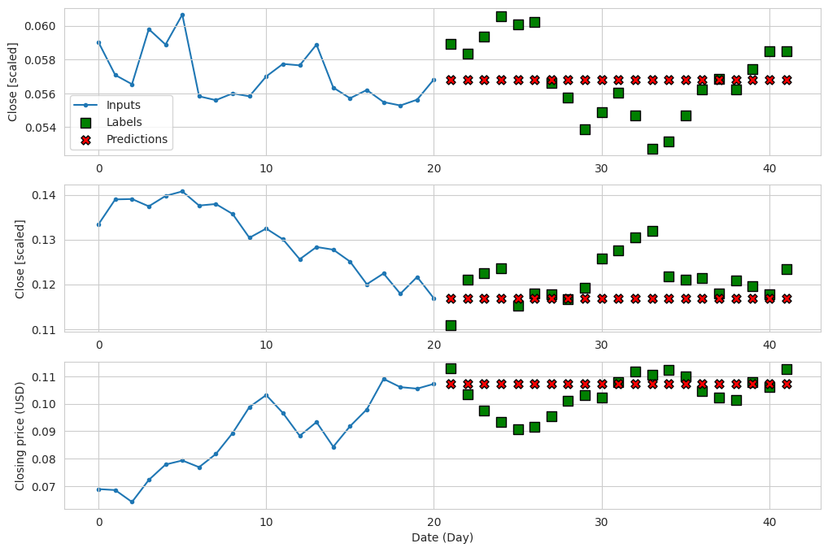

```python
multi_window.plot(baseline_last)
```

Next, let’s implement a baseline model that repeats the input sequence (21 day),This means that the prediction for the next 21 days will simply be the last known 21 days of data as it is.

```python
class RepeatBaseline(Model):
    def __init__(self, label_index=None):
        super().__init__()
        self.label_index = label_index

    def call(self, inputs):
        return inputs[:, :, self.label_index:]
```

```python
baseline_repeat = RepeatBaseline(label_index=column_indices['Close'])

baseline_repeat.compile(loss=MeanSquaredError(), metrics=[MeanAbsoluteError()])

val_performance['Baseline - Repeat'] = baseline_repeat.evaluate(multi_window.val)
performance['Baseline - Repeat'] = baseline_repeat.evaluate(multi_window.test, verbose=0)
```

```
38/38 ━━━━━━━━━━━━━━━━━━━━ 0s 1ms/step - loss: 7.7380 - mean_absolute_error: 1.7175
```

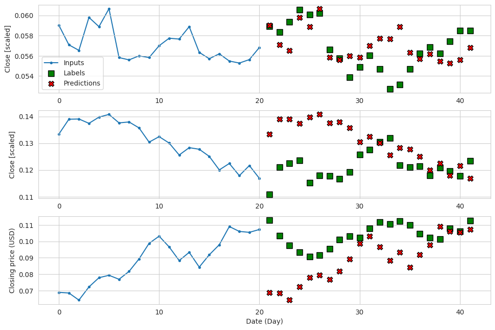

```python
multi_window.plot(baseline_repeat)
```

We can see that the predictions are equal to the input sequence, which is the expected behavior for this baseline model.

#### Second: Linear model

```python
label_index = column_indices['Close']
num_features = train_df.shape[1]

linear = Sequential([
    Dense(1, kernel_initializer=tf.initializers.zeros)
])
```

```python
history = compile_and_fit(linear, multi_window)

val_performance['Linear'] = linear.evaluate(multi_window.val)
performance['Linear'] = linear.evaluate(multi_window.test, verbose=0)
```

```
135/135 ━━━━━━━━━━━━━━━━━━━━ 1s 5ms/step - loss: 0.0217 - mean_absolute_error: 0.0848 - val_loss: 5.9727 - val_mean_absolute_error: 1.9052
135/135 ━━━━━━━━━━━━━━━━━━━━ 1s 3ms/step - loss: 0.0058 - mean_absolute_error: 0.0476 - val_loss: 2.4963 - val_mean_absolute_error: 1.1900
135/135 ━━━━━━━━━━━━━━━━━━━━ 1s 3ms/step - loss: 0.0027 - mean_absolute_error: 0.0327 - val_loss: 1.0300 - val_mean_absolute_error: 0.7080
135/135 ━━━━━━━━━━━━━━━━━━━━ 0s 3ms/step - loss: 0.0014 - mean_absolute_error: 0.0245 - val_loss: 0.5306 - val_mean_absolute_error: 0.4558
135/135 ━━━━━━━━━━━━━━━━━━━━ 0s 3ms/step - loss: 9.7407e-04 - mean_absolute_error: 0.0211 - val_loss: 0.3835 - val_mean_absolute_error: 0.3653
135/135 ━━━━━━━━━━━━━━━━━━━━ 0s 3ms/step - loss: 7.9192e-04 - mean_absolute_error: 0.0190 - val_loss: 0.3469 - val_mean_absolute_error: 0.3415
135/135 ━━━━━━━━━━━━━━━━━━━━ 0s 3ms/step - loss: 7.5281e-04 - mean_absolute_error: 0.0182 - val_loss: 0.3412 - val_mean_absolute_error: 0.3365
135/135 ━━━━━━━━━━━━━━━━━━━━ 0s 3ms/step - loss: 7.1832e-04 - mean_absolute_error: 0.0176 - val_loss: 0.3434 - val_mean_absolute_error: 0.3376
135/135 ━━━━━━━━━━━━━━━━━━━━ 0s 3ms/step - loss: 7.0698e-04 - mean_absolute_error: 0.0173 - val_loss: 0.3460 - val_mean_absolute_error: 0.3392
135/135 ━━━━━━━━━━━━━━━━━━━━ 0s 3ms/step - loss: 7.0882e-04 - mean_absolute_error: 0.0172 - val_loss: 0.3501 - val_mean_absolute_error: 0.3414
38/38 ━━━━━━━━━━━━━━━━━━━━ 0s 2ms/step - loss: 0.3237 - mean_absolute_error: 0.3284
```

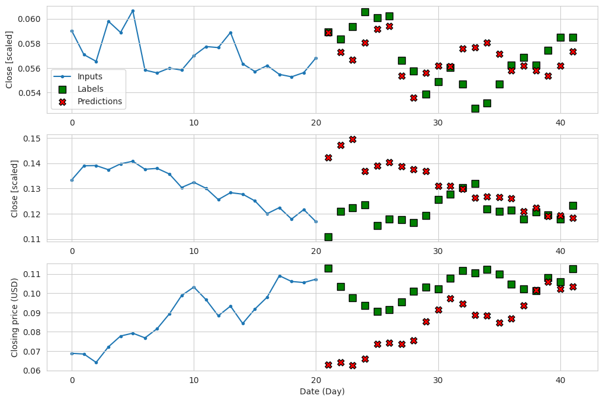

```python
multi_window.plot(linear)
```

Predictions generated from a linear model

#### hird: Deep neural network - Dense Model

```python
dense = Sequential([
    Dense(64, activation='relu'),
    Dense(64, activation='relu'),
    Dense(1, kernel_initializer=tf.initializers.zeros),
])

history = compile_and_fit(dense, multi_window)

val_performance['Dense'] = dense.evaluate(multi_window.val)
performance['Dense'] = dense.evaluate(multi_window.test, verbose=0)
```

```
135/135 ━━━━━━━━━━━━━━━━━━━━ 1s 5ms/step - loss: 0.0143 - mean_absolute_error: 0.0694 - val_loss: 0.3501 - val_mean_absolute_error: 0.3373
135/135 ━━━━━━━━━━━━━━━━━━━━ 1s 4ms/step - loss: 6.6663e-04 - mean_absolute_error: 0.0169 - val_loss: 0.3474 - val_mean_absolute_error: 0.3353
135/135 ━━━━━━━━━━━━━━━━━━━━ 1s 4ms/step - loss: 6.2909e-04 - mean_absolute_error: 0.0166 - val_loss: 0.4056 - val_mean_absolute_error: 0.3707
135/135 ━━━━━━━━━━━━━━━━━━━━ 1s 4ms/step - loss: 5.7702e-04 - mean_absolute_error: 0.0161 - val_loss: 0.4033 - val_mean_absolute_error: 0.3678
135/135 ━━━━━━━━━━━━━━━━━━━━ 1s 4ms/step - loss: 5.6958e-04 - mean_absolute_error: 0.0162 - val_loss: 0.3831 - val_mean_absolute_error: 0.3547
38/38 ━━━━━━━━━━━━━━━━━━━━ 0s 2ms/step - loss: 0.4343 - mean_absolute_error: 0.3714
```

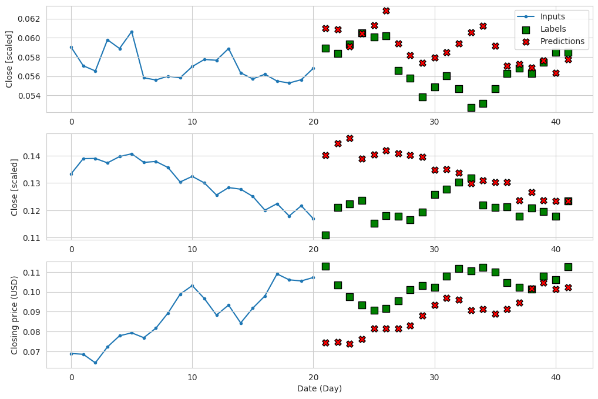

```python
multi_window.plot(dense)
```

Predections genertaed from Dense Model

#### Fourth: Long short-term memory (LSTM) model

Long short-term memory (LSTM) is a deep learning architecture that is a subtype of RNN. LSTM addresses the problem of short-term memory by adding the cell state. This allows for past information to flow through the network for a longer period of time, meaning that the network still carries information from early values in the sequence.

The main advantage of the long short-term memory (LSTM) model is that it keeps information from the past in memory. This makes it especially suitable for treating sequences of data, like time series. It allows us to combine information from the present and the past to produce a prediction.

- We’ll feed the input sequence through an LSTM layer before sending it to the output layer, which remains a Dense layer with one neuron.
- We’ll then train the model and store its performance in the dictionary for comparison at the end.

```python
lstm_model = Sequential([
    LSTM(32, return_sequences=True),
    Dense(1, kernel_initializer=tf.initializers.zeros),
])

history = compile_and_fit(lstm_model, multi_window)

val_performance['LSTM'] = lstm_model.evaluate(multi_window.val)
performance['LSTM'] = lstm_model.evaluate(multi_window.test, verbose=0)
```

```
135/135 ━━━━━━━━━━━━━━━━━━━━ 3s 11ms/step - loss: 0.0170 - mean_absolute_error: 0.0736 - val_loss: 10.4204 - val_mean_absolute_error: 2.2056
135/135 ━━━━━━━━━━━━━━━━━━━━ 1s 9ms/step - loss: 0.0017 - mean_absolute_error: 0.0232 - val_loss: 9.3455 - val_mean_absolute_error: 2.0100
135/135 ━━━━━━━━━━━━━━━━━━━━ 1s 9ms/step - loss: 0.0011 - mean_absolute_error: 0.0202 - val_loss: 8.6999 - val_mean_absolute_error: 1.9057
135/135 ━━━━━━━━━━━━━━━━━━━━ 1s 9ms/step - loss: 8.7756e-04 - mean_absolute_error: 0.0189 - val_loss: 8.3813 - val_mean_absolute_error: 1.8765
135/135 ━━━━━━━━━━━━━━━━━━━━ 2s 11ms/step - loss: 7.4961e-04 - mean_absolute_error: 0.0180 - val_loss: 8.0626 - val_mean_absolute_error: 1.8277
135/135 ━━━━━━━━━━━━━━━━━━━━ 1s 9ms/step - loss: 6.5821e-04 - mean_absolute_error: 0.0172 - val_loss: 7.8642 - val_mean_absolute_error: 1.8083
135/135 ━━━━━━━━━━━━━━━━━━━━ 1s 9ms/step - loss: 6.3592e-04 - mean_absolute_error: 0.0172 - val_loss: 7.7024 - val_mean_absolute_error: 1.7764
135/135 ━━━━━━━━━━━━━━━━━━━━ 1s 9ms/step - loss: 5.8255e-04 - mean_absolute_error: 0.0167 - val_loss: 7.6145 - val_mean_absolute_error: 1.7750
135/135 ━━━━━━━━━━━━━━━━━━━━ 1s 9ms/step - loss: 5.7502e-04 - mean_absolute_error: 0.0166 - val_loss: 7.5146 - val_mean_absolute_error: 1.7622
135/135 ━━━━━━━━━━━━━━━━━━━━ 1s 9ms/step - loss: 5.5502e-04 - mean_absolute_error: 0.0163 - val_loss: 7.4931 - val_mean_absolute_error: 1.7714
135/135 ━━━━━━━━━━━━━━━━━━━━ 1s 9ms/step - loss: 5.4910e-04 - mean_absolute_error: 0.0162 - val_loss: 7.3192 - val_mean_absolute_error: 1.7210
135/135 ━━━━━━━━━━━━━━━━━━━━ 1s 9ms/step - loss: 6.2073e-04 - mean_absolute_error: 0.0172 - val_loss: 7.4349 - val_mean_absolute_error: 1.7619
135/135 ━━━━━━━━━━━━━━━━━━━━ 1s 9ms/step - loss: 5.2511e-04 - mean_absolute_error: 0.0159 - val_loss: 7.4666 - val_mean_absolute_error: 1.7841
135/135 ━━━━━━━━━━━━━━━━━━━━ 1s 10ms/step - loss: 5.6663e-04 - mean_absolute_error: 0.0165 - val_loss: 7.4288 - val_mean_absolute_error: 1.7740
38/38 ━━━━━━━━━━━━━━━━━━━━ 0s 4ms/step - loss: 6.7605 - mean_absolute_error: 1.7031
```

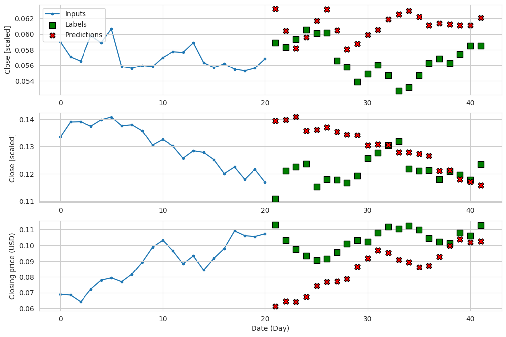

```python
multi_window.plot(lstm_model)
```

Predictions generated from the LSTM model.

#### Fifth: Convolutional neural network (CNN)

Convolutional neural network (CNN)

- A convolutional neural network (CNN) is a deep learning architecture that uses the convolution operation. This allows the network to reduce the feature space, effectively filtering the inputs and preventing overfitting.
- The convolution is performed with a kernel, which is also trained during model fitting. The stride of the kernel determines the number of steps it shifts at each step of the convolution. In time series forecasting, only 1D convolution is used.
- To avoid reducing the feature space too quickly, we can use padding, which adds zeros before and after the input vector. This keeps the output dimension the same as the original feature vector, allowing us to stack more convolution layers, which in turn allows the network to process the features for a longer time. AThe main advantage of convolutional neural network (CNN) is that it uses the convolution function to reduce the feature space. This effectively filters our time series and performs feature selection. Furthermore, a CNN is faster to train than an LSTM since the operations are parallelized, whereas the LSTM must treat one element of the sequence at a time.

Because the convolution operation reduces the feature space, we must provide a slightly longer input sequence to make sure that the output sequence contains 21 timesteps. How much longer it needs to be depends on the length of the kernel that performs the convolution operation. In this case, we’ll use a kernel length of 3.

This is an arbitrary choice, Given that we need 21 labels, we can calculate the input sequence using equation:

$$input length = label length + kernel length – 1$$

This forces us to define a window of data specifically for the CNN model. Note that since we are defining a new window of data, the sample batch used for plotting will differ from the one used so far.

```python
KERNEL_WIDTH = 3
LABEL_WIDTH = 21
INPUT_WIDTH = LABEL_WIDTH + KERNEL_WIDTH - 1
```

```python
cnn_multi_window = DataWindow(input_width=INPUT_WIDTH, label_width=LABEL_WIDTH, shift=21, label_columns=['Close'])
```

```python
cnn_model = Sequential([
    Conv1D(32, activation='relu', kernel_size=(KERNEL_WIDTH)),
    Dense(units=32, activation='relu'),
    Dense(1, kernel_initializer=tf.initializers.zeros),
])

history = compile_and_fit(cnn_model, cnn_multi_window)

val_performance['CNN'] = cnn_model.evaluate(cnn_multi_window.val)
performance['CNN'] = cnn_model.evaluate(cnn_multi_window.test, verbose=0)
```

```
135/135 ━━━━━━━━━━━━━━━━━━━━ 2s 5ms/step - loss: 0.0134 - mean_absolute_error: 0.0681 - val_loss: 0.3643 - val_mean_absolute_error: 0.3490
135/135 ━━━━━━━━━━━━━━━━━━━━ 1s 4ms/step - loss: 6.8042e-04 - mean_absolute_error: 0.0177 - val_loss: 0.3597 - val_mean_absolute_error: 0.3465
135/135 ━━━━━━━━━━━━━━━━━━━━ 1s 4ms/step - loss: 6.6731e-04 - mean_absolute_error: 0.0172 - val_loss: 0.3555 - val_mean_absolute_error: 0.3436
135/135 ━━━━━━━━━━━━━━━━━━━━ 1s 4ms/step - loss: 6.1506e-04 - mean_absolute_error: 0.0167 - val_loss: 0.3572 - val_mean_absolute_error: 0.3456
135/135 ━━━━━━━━━━━━━━━━━━━━ 1s 4ms/step - loss: 6.5154e-04 - mean_absolute_error: 0.0174 - val_loss: 0.3550 - val_mean_absolute_error: 0.3420
135/135 ━━━━━━━━━━━━━━━━━━━━ 1s 4ms/step - loss: 5.8586e-04 - mean_absolute_error: 0.0165 - val_loss: 0.3713 - val_mean_absolute_error: 0.3510
135/135 ━━━━━━━━━━━━━━━━━━━━ 1s 4ms/step - loss: 5.6862e-04 - mean_absolute_error: 0.0162 - val_loss: 0.3815 - val_mean_absolute_error: 0.3563
135/135 ━━━━━━━━━━━━━━━━━━━━ 1s 4ms/step - loss: 5.7217e-04 - mean_absolute_error: 0.0162 - val_loss: 0.3542 - val_mean_absolute_error: 0.3443
135/135 ━━━━━━━━━━━━━━━━━━━━ 1s 4ms/step - loss: 6.2552e-04 - mean_absolute_error: 0.0172 - val_loss: 0.3691 - val_mean_absolute_error: 0.3490
135/135 ━━━━━━━━━━━━━━━━━━━━ 1s 5ms/step - loss: 5.8660e-04 - mean_absolute_error: 0.0165 - val_loss: 0.4233 - val_mean_absolute_error: 0.3806
135/135 ━━━━━━━━━━━━━━━━━━━━ 1s 4ms/step - loss: 5.3907e-04 - mean_absolute_error: 0.0158 - val_loss: 0.3627 - val_mean_absolute_error: 0.3451
38/38 ━━━━━━━━━━━━━━━━━━━━ 0s 2ms/step - loss: 0.3327 - mean_absolute_error: 0.3320
```

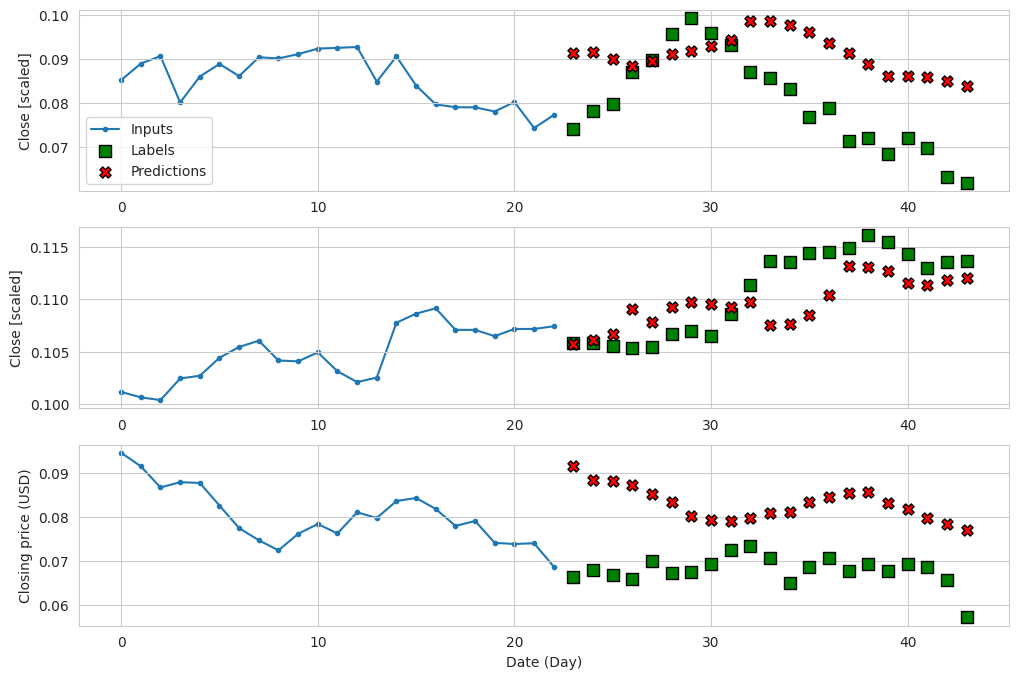

```python
cnn_multi_window.plot(cnn_model)
```

shows that the input sequence differs from our previous methods because working with a CNN involves windowing the data again to account for the convolution kernel length. The training, validation, and test sets remain unchanged, so it is still valid to compare all the models’ performance.

#### Sixth: Combining a CNN with an LSTM

We know that:

- LSTM is good at treating sequences of data,
- While CNN can filter a sequence of data. Therefore, it is a reasonable hypothesis that filtering our input sequence before feeding it to an LSTM might improve the performance, It is interesting to test whether combining CNN with LSTM can result in a better-performing model.

We’ll:

- Feed the input sequence to a Conv1D layer,but
- Use an LSTM layer for learning this time.

Then we’ll send the information to the output layer. Again, we’ll train the model and store its performance.

```python
cnn_lstm_model = Sequential([
    Conv1D(32, activation='relu', kernel_size=(KERNEL_WIDTH)),
    LSTM(32, return_sequences=True),
    Dense(1, kernel_initializer=tf.initializers.zeros),
])
```

```python
history = compile_and_fit(cnn_lstm_model, cnn_multi_window)

val_performance['CNN + LSTM'] = cnn_lstm_model.evaluate(cnn_multi_window.val)
performance['CNN + LSTM'] = cnn_lstm_model.evaluate(cnn_multi_window.test, verbose=0)
```

```
135/135 ━━━━━━━━━━━━━━━━━━━━ 3s 12ms/step - loss: 0.0142 - mean_absolute_error: 0.0671 - val_loss: 10.4295 - val_mean_absolute_error: 2.1836
135/135 ━━━━━━━━━━━━━━━━━━━━ 2s 11ms/step - loss: 9.5357e-04 - mean_absolute_error: 0.0198 - val_loss: 10.0596 - val_mean_absolute_error: 2.1213
135/135 ━━━━━━━━━━━━━━━━━━━━ 1s 11ms/step - loss: 7.0934e-04 - mean_absolute_error: 0.0179 - val_loss: 9.8440 - val_mean_absolute_error: 2.0698
135/135 ━━━━━━━━━━━━━━━━━━━━ 2s 12ms/step - loss: 6.1569e-04 - mean_absolute_error: 0.0171 - val_loss: 9.7641 - val_mean_absolute_error: 2.0607
135/135 ━━━━━━━━━━━━━━━━━━━━ 2s 11ms/step - loss: 5.9728e-04 - mean_absolute_error: 0.0169 - val_loss: 9.7858 - val_mean_absolute_error: 2.0739
135/135 ━━━━━━━━━━━━━━━━━━━━ 2s 11ms/step - loss: 5.7904e-04 - mean_absolute_error: 0.0168 - val_loss: 9.7727 - val_mean_absolute_error: 2.0759
135/135 ━━━━━━━━━━━━━━━━━━━━ 1s 11ms/step - loss: 5.5126e-04 - mean_absolute_error: 0.0164 - val_loss: 9.6515 - val_mean_absolute_error: 2.0332
135/135 ━━━━━━━━━━━━━━━━━━━━ 2s 11ms/step - loss: 5.5635e-04 - mean_absolute_error: 0.0167 - val_loss: 9.6909 - val_mean_absolute_error: 2.0633
135/135 ━━━━━━━━━━━━━━━━━━━━ 2s 11ms/step - loss: 5.8434e-04 - mean_absolute_error: 0.0168 - val_loss: 9.7115 - val_mean_absolute_error: 2.0605
135/135 ━━━━━━━━━━━━━━━━━━━━ 1s 11ms/step - loss: 5.3456e-04 - mean_absolute_error: 0.0162 - val_loss: 9.6966 - val_mean_absolute_error: 2.0591
38/38 ━━━━━━━━━━━━━━━━━━━━ 0s 4ms/step - loss: 10.2042 - mean_absolute_error: 2.1030
```

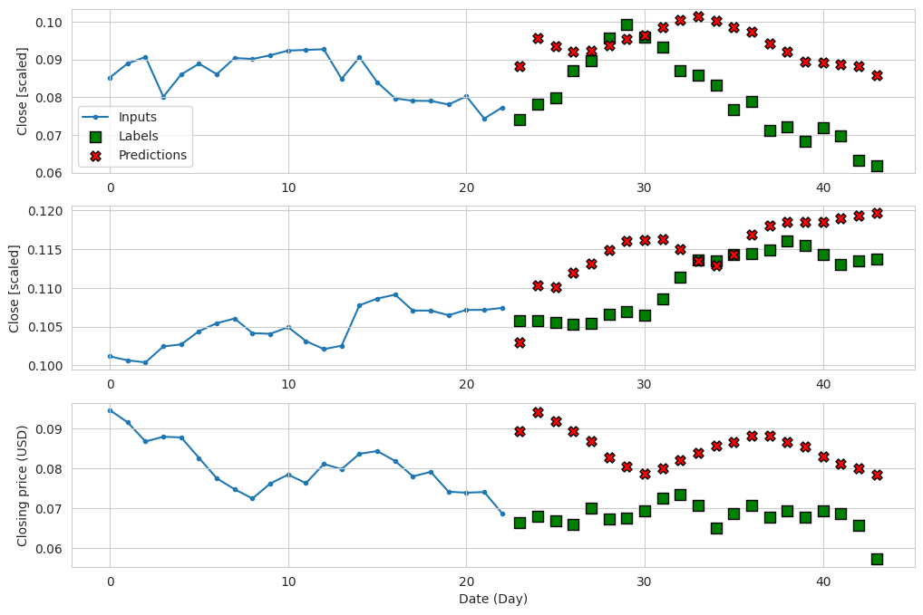

```python
cnn_multi_window.plot(cnn_lstm_model)
```

Predictions from a CNN combined with an LSTM model

#### Seventh: The Autoregressive LSTM model - Using Predictions To Make More Predictions

The final model that we’ll implement is an autoregressive LSTM (ARLSTM) model. Instead of generating the entire output sequence in a single shot, the Autoregressive model will generate one prediction at a time and use that prediction as an input to generate the next one.

This kind of architecture is present in state-of-the-art forecasting models, but it is worth nothing that Autoregressive deep learning models come with a major caveat, which is the accumulation of error. If the model generates a very bad first prediction, this mistake will be carried on to the next predictions, which will magnify the errors. That error accumulates as it is fed back into the model, meaning that later predictions will have a larger error than earlier predictions. Nevertheless, it is worth testing this model and have this model in our toolbox of time series forecasting methods.

Let's see if it works well in our situation.

The first step is defining the class that implements the ARLSTM model.

```python
class AutoRegressive(Model):
    def __init__(self, units, out_steps):
        super().__init__()
        self.out_steps = out_steps
        self.units = units
        self.lstm_cell = LSTMCell(units)
        self.lstm_rnn = RNN(self.lstm_cell, return_state=True)
        self.dense = Dense(train_df.shape[1])

    def warmup(self, inputs):
        x, *state = self.lstm_rnn(inputs)
        prediction = self.dense(x)

        return prediction, state

    def call(self, inputs, training=None):
        predictions = []
        prediction, state = self.warmup(inputs)

        predictions.append(prediction)

        for n in range(1, self.out_steps):
            x = prediction
            x, state = self.lstm_cell(x, states=state, training=training)

            prediction = self.dense(x)
            predictions.append(prediction)

        predictions = tf.stack(predictions)
        predictions = tf.transpose(predictions, [1, 0, 2])

        return predictions
```

```python
AR_LSTM = AutoRegressive(units=32, out_steps=21)
```

```python
history = compile_and_fit(AR_LSTM, multi_window)

val_performance['ARLSTM'] = AR_LSTM.evaluate(multi_window.val)
performance['ARLSTM'] = AR_LSTM.evaluate(multi_window.test, verbose=0)
```

```
135/135 ━━━━━━━━━━━━━━━━━━━━ 7s 22ms/step - loss: 0.0139 - mean_absolute_error: 0.0644 - val_loss: 11.0975 - val_mean_absolute_error: 2.2824
135/135 ━━━━━━━━━━━━━━━━━━━━ 2s 16ms/step - loss: 7.5854e-04 - mean_absolute_error: 0.0187 - val_loss: 10.8502 - val_mean_absolute_error: 2.2320
135/135 ━━━━━━━━━━━━━━━━━━━━ 2s 14ms/step - loss: 8.2681e-04 - mean_absolute_error: 0.0191 - val_loss: 11.0197 - val_mean_absolute_error: 2.2648
135/135 ━━━━━━━━━━━━━━━━━━━━ 2s 15ms/step - loss: 6.0031e-04 - mean_absolute_error: 0.0167 - val_loss: 10.9231 - val_mean_absolute_error: 2.2466
135/135 ━━━━━━━━━━━━━━━━━━━━ 2s 14ms/step - loss: 5.7356e-04 - mean_absolute_error: 0.0161 - val_loss: 10.7707 - val_mean_absolute_error: 2.2110
135/135 ━━━━━━━━━━━━━━━━━━━━ 2s 15ms/step - loss: 4.7733e-04 - mean_absolute_error: 0.0145 - val_loss: 10.7527 - val_mean_absolute_error: 2.2090
135/135 ━━━━━━━━━━━━━━━━━━━━ 2s 16ms/step - loss: 5.0870e-04 - mean_absolute_error: 0.0150 - val_loss: 10.9022 - val_mean_absolute_error: 2.2436
135/135 ━━━━━━━━━━━━━━━━━━━━ 2s 17ms/step - loss: 5.6450e-04 - mean_absolute_error: 0.0156 - val_loss: 11.0381 - val_mean_absolute_error: 2.2639
135/135 ━━━━━━━━━━━━━━━━━━━━ 2s 16ms/step - loss: 4.9664e-04 - mean_absolute_error: 0.0149 - val_loss: 10.8519 - val_mean_absolute_error: 2.2211
38/38 ━━━━━━━━━━━━━━━━━━━━ 0s 5ms/step - loss: 10.0382 - mean_absolute_error: 2.1137
```

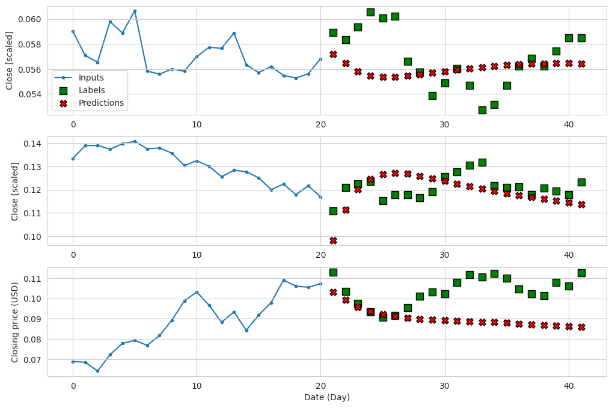

```python
multi_window.plot(AR_LSTM)
```

Predictions from the ARLSTM model

#### Selecting Best Model

```python
mae_val = [v[1] for v in val_performance.values()]
mae_test = [v[1] for v in performance.values()]
```

[figure not shown]

```python
x = np.arange(len(performance))

fig, ax = plt.subplots()
ax.bar(x - 0.15, mae_val, width=0.25, color='black', edgecolor='black', label='Validation')
ax.bar(x + 0.15, mae_test, width=0.25, color='white', edgecolor='black', hatch='/', label='Test')
ax.set_ylabel('Mean absolute error')
ax.set_xlabel('Models')


font_prop = font_manager.FontProperties( size=20)

for index, value in enumerate(mae_val):
    plt.text(x=index - 0.15, y=value+0.005, s=str(round(value, 3)), ha='center',fontproperties=font_prop)

for index, value in enumerate(mae_test):
    plt.text(x=index + 0.15, y=value+0.0025, s=str(round(value, 3)), ha='center',fontproperties=font_prop)

# plt.ylim(0, 0.33)
plt.xticks(ticks=x, labels=performance.keys())
plt.legend(loc='best')

plt.legend(fontsize=25) # using a size in points

plt.tight_layout()
plt.figure(figsize=(10,6))
```

Comparing the MAE of all models tested

```python
model_names = ['Baseline-Last', 'Baseline-Repeat', 'Linear', 'Dense', 'LSTM', 'CNN', 'LSTM+CNN', 'ARLSTM']
data = {'Test - MAE': mae_test, 'Validation - MAE': mae_val}
df = pd.DataFrame(data, index=model_names)
df_sorted = df.sort_values(by='Test - MAE', ascending=True)
df_sorted.T
```

[output not shown]

### Sentiment analysis after noise reduction test

```python
# Load datasets
sentiment_data = pd.read_csv('nvidia_sentimental_analisis.csv')
stock_price_data = pd.read_csv('NvidiaStockPrice.csv')

sentiment_data = sentiment_data.replace({'sentiment_rf': {'neutral': 0, 'positive': 1, 'negative': -1}})
sentiment_data = sentiment_data.replace({'sentiment_nn': {'neutral': 0, 'positive': 1, 'negative': -1}})
sentiment_data['sentiment_rf'] = sentiment_data['sentiment_rf'].astype('int')
sentiment_data['sentiment_nn'] = sentiment_data['sentiment_nn'].astype('int')

# Quick data exploration
print(sentiment_data.head())
print(stock_price_data.head())

# Check for missing values
print(sentiment_data.isnull().sum())
print(stock_price_data.isnull().sum())
```

```
         Date                                            Summary  \
0  2024-06-14  As bolsas de Nova York fecharam sem direção ún...
1  2024-06-14  Os futuros dos índices de ações dos EUA tivera...
2  2024-06-14  Os acionistas da Tesla (NASDAQ:TSLA) mostraram...
3  2024-06-13  Em um movimento recente, Mark A. Stevens, dire...
4  2024-06-13  (Bloomberg) -- A Broadcom experimentou uma alt...

   sentiment_rf  sentiment_nn
0             0             1
1             1             1
2             0             0
3             0             0
4             0             0
         Date      Open      High       Low     Close  Adj Close      Volume
0  1999-01-22  0.043750  0.048828  0.038802  0.041016   0.037621  2714688000
1  1999-01-25  0.044271  0.045833  0.041016  0.045313   0.041562   510480000
2  1999-01-26  0.045833  0.046745  0.041146  0.041797   0.038337   343200000
3  1999-01-27  0.041927  0.042969  0.039583  0.041667   0.038218   244368000
4  1999-01-28  0.041667  0.041927  0.041276  0.041536   0.038098   227520000
Date            0
Summary         0
sentiment_rf    0
sentiment_nn    0
dtype: int64
Date         0
Open         0
High         0
Low          0
Close        0
Adj Close    0
Volume       0
dtype: int64
```

```python
# Convert 'Date' to datetime format
sentiment_data['Date'] = pd.to_datetime(sentiment_data['Date'])
stock_price_data['Date'] = pd.to_datetime(stock_price_data['Date'])

# Merge datasets
merged_data = pd.merge(stock_price_data, sentiment_data, on='Date', how='left')
```

```python
# Apply moving average to smooth stock price
merged_data['Close_SMA_10'] = merged_data['Close'].rolling(window=10).mean()

# Fill missing sentiment scores with interpolation or rolling means
merged_data['sentiment_rf'].fillna(merged_data['sentiment_rf'].rolling(window=5).mean(), inplace=True)
merged_data['sentiment_nn'].fillna(merged_data['sentiment_nn'].rolling(window=5).mean(), inplace=True)
```

```python
# Lag features
merged_data['Close_Lag_1'] = merged_data['Close'].shift(1)
merged_data['Close_Lag_2'] = merged_data['Close'].shift(2)

# Rolling window features
merged_data['sentiment_rf_score_Rolling_7'] = merged_data['sentiment_rf'].rolling(window=7).mean()
merged_data['sentiment_nn_score_Rolling_7'] = merged_data['sentiment_nn'].rolling(window=7).mean()
```

```python
# Define the target variable
merged_data['Target'] = merged_data['Close'].shift(-1)
merged_data.dropna(inplace=True)  # Drop rows with NaN values after shifting
```

```python
from sklearn.preprocessing import MinMaxScaler
from sklearn.model_selection import train_test_split

# Selecting relevant features
features = ['Close', 'Close_SMA_10', 'sentiment_rf', 'sentiment_nn', 'Close_Lag_1', 'Close_Lag_2']
target = 'Target'

# Scaling data
scaler = MinMaxScaler()
scaled_data = scaler.fit_transform(merged_data[features + [target]])

# Splitting data into training and testing sets
train_size = int(len(scaled_data) * 0.8)
train_data, test_data = scaled_data[:train_size], scaled_data[train_size:]

# Reshape data for LSTM model
def create_sequences(data, seq_length):
    X, y = [], []
    for i in range(len(data) - seq_length):
        X.append(data[i:i + seq_length])
        y.append(data[i + seq_length, -1])
    return np.array(X), np.array(y)

seq_length = 10
X_train, y_train = create_sequences(train_data, seq_length)
X_test, y_test = create_sequences(test_data, seq_length)
```

```python
# LSTM Model Implementation
from keras.models import Sequential
from keras.layers import LSTM, Dense, Dropout

# Define LSTM model
model = Sequential()
model.add(LSTM(50, return_sequences=True, input_shape=(X_train.shape[1], X_train.shape[2])))
model.add(Dropout(0.2))
model.add(LSTM(50, return_sequences=False))
model.add(Dropout(0.2))
model.add(Dense(1))

# Compile the model
model.compile(optimizer='adam', loss='mean_squared_error')

# Train the model
history = model.fit(X_train, y_train, epochs=50, batch_size=32, validation_split=0.2, shuffle=False)
```

```
7/7 ━━━━━━━━━━━━━━━━━━━━ 3s 82ms/step - loss: 0.1174 - val_loss: 0.0019
7/7 ━━━━━━━━━━━━━━━━━━━━ 0s 15ms/step - loss: 0.0316 - val_loss: 0.0013
7/7 ━━━━━━━━━━━━━━━━━━━━ 0s 20ms/step - loss: 0.0150 - val_loss: 0.0542
7/7 ━━━━━━━━━━━━━━━━━━━━ 0s 15ms/step - loss: 0.0088 - val_loss: 0.0251
7/7 ━━━━━━━━━━━━━━━━━━━━ 0s 20ms/step - loss: 0.0052 - val_loss: 0.0035
7/7 ━━━━━━━━━━━━━━━━━━━━ 0s 32ms/step - loss: 0.0084 - val_loss: 0.0062
7/7 ━━━━━━━━━━━━━━━━━━━━ 0s 17ms/step - loss: 0.0052 - val_loss: 0.0099
7/7 ━━━━━━━━━━━━━━━━━━━━ 0s 15ms/step - loss: 0.0050 - val_loss: 0.0058
7/7 ━━━━━━━━━━━━━━━━━━━━ 0s 20ms/step - loss: 0.0047 - val_loss: 0.0043
7/7 ━━━━━━━━━━━━━━━━━━━━ 0s 14ms/step - loss: 0.0048 - val_loss: 0.0078
7/7 ━━━━━━━━━━━━━━━━━━━━ 0s 13ms/step - loss: 0.0035 - val_loss: 0.0025
7/7 ━━━━━━━━━━━━━━━━━━━━ 0s 18ms/step - loss: 0.0039 - val_loss: 0.0023
7/7 ━━━━━━━━━━━━━━━━━━━━ 0s 14ms/step - loss: 0.0036 - val_loss: 0.0048
7/7 ━━━━━━━━━━━━━━━━━━━━ 0s 15ms/step - loss: 0.0035 - val_loss: 0.0054
7/7 ━━━━━━━━━━━━━━━━━━━━ 0s 17ms/step - loss: 0.0032 - val_loss: 0.0032
7/7 ━━━━━━━━━━━━━━━━━━━━ 0s 14ms/step - loss: 0.0032 - val_loss: 0.0025
7/7 ━━━━━━━━━━━━━━━━━━━━ 0s 12ms/step - loss: 0.0035 - val_loss: 0.0015
7/7 ━━━━━━━━━━━━━━━━━━━━ 0s 18ms/step - loss: 0.0037 - val_loss: 0.0027
7/7 ━━━━━━━━━━━━━━━━━━━━ 0s 14ms/step - loss: 0.0028 - val_loss: 0.0044
7/7 ━━━━━━━━━━━━━━━━━━━━ 0s 15ms/step - loss: 0.0033 - val_loss: 0.0021
7/7 ━━━━━━━━━━━━━━━━━━━━ 0s 17ms/step - loss: 0.0031 - val_loss: 0.0040
7/7 ━━━━━━━━━━━━━━━━━━━━ 0s 12ms/step - loss: 0.0036 - val_loss: 0.0030
7/7 ━━━━━━━━━━━━━━━━━━━━ 0s 12ms/step - loss: 0.0036 - val_loss: 0.0011
7/7 ━━━━━━━━━━━━━━━━━━━━ 0s 17ms/step - loss: 0.0027 - val_loss: 0.0046
7/7 ━━━━━━━━━━━━━━━━━━━━ 0s 13ms/step - loss: 0.0029 - val_loss: 0.0021
7/7 ━━━━━━━━━━━━━━━━━━━━ 0s 12ms/step - loss: 0.0029 - val_loss: 8.7324e-04
7/7 ━━━━━━━━━━━━━━━━━━━━ 0s 16ms/step - loss: 0.0028 - val_loss: 0.0043
7/7 ━━━━━━━━━━━━━━━━━━━━ 0s 13ms/step - loss: 0.0049 - val_loss: 0.0035
7/7 ━━━━━━━━━━━━━━━━━━━━ 0s 12ms/step - loss: 0.0033 - val_loss: 0.0011
7/7 ━━━━━━━━━━━━━━━━━━━━ 0s 18ms/step - loss: 0.0039 - val_loss: 0.0050
7/7 ━━━━━━━━━━━━━━━━━━━━ 0s 15ms/step - loss: 0.0026 - val_loss: 0.0013
7/7 ━━━━━━━━━━━━━━━━━━━━ 0s 15ms/step - loss: 0.0032 - val_loss: 0.0034
7/7 ━━━━━━━━━━━━━━━━━━━━ 0s 19ms/step - loss: 0.0028 - val_loss: 0.0018
7/7 ━━━━━━━━━━━━━━━━━━━━ 0s 15ms/step - loss: 0.0028 - val_loss: 0.0022
7/7 ━━━━━━━━━━━━━━━━━━━━ 0s 15ms/step - loss: 0.0028 - val_loss: 0.0020
7/7 ━━━━━━━━━━━━━━━━━━━━ 0s 18ms/step - loss: 0.0029 - val_loss: 0.0016
7/7 ━━━━━━━━━━━━━━━━━━━━ 0s 12ms/step - loss: 0.0026 - val_loss: 0.0017
7/7 ━━━━━━━━━━━━━━━━━━━━ 0s 12ms/step - loss: 0.0030 - val_loss: 0.0016
7/7 ━━━━━━━━━━━━━━━━━━━━ 0s 19ms/step - loss: 0.0028 - val_loss: 0.0030
7/7 ━━━━━━━━━━━━━━━━━━━━ 0s 14ms/step - loss: 0.0042 - val_loss: 0.0022
7/7 ━━━━━━━━━━━━━━━━━━━━ 0s 13ms/step - loss: 0.0030 - val_loss: 0.0022
7/7 ━━━━━━━━━━━━━━━━━━━━ 0s 21ms/step - loss: 0.0038 - val_loss: 0.0039
7/7 ━━━━━━━━━━━━━━━━━━━━ 0s 15ms/step - loss: 0.0032 - val_loss: 0.0016
7/7 ━━━━━━━━━━━━━━━━━━━━ 0s 16ms/step - loss: 0.0046 - val_loss: 0.0067
7/7 ━━━━━━━━━━━━━━━━━━━━ 0s 20ms/step - loss: 0.0029 - val_loss: 0.0013
7/7 ━━━━━━━━━━━━━━━━━━━━ 0s 14ms/step - loss: 0.0036 - val_loss: 0.0054
7/7 ━━━━━━━━━━━━━━━━━━━━ 0s 13ms/step - loss: 0.0024 - val_loss: 8.4624e-04
7/7 ━━━━━━━━━━━━━━━━━━━━ 0s 20ms/step - loss: 0.0034 - val_loss: 0.0044
7/7 ━━━━━━━━━━━━━━━━━━━━ 0s 12ms/step - loss: 0.0030 - val_loss: 0.0023
7/7 ━━━━━━━━━━━━━━━━━━━━ 0s 12ms/step - loss: 0.0026 - val_loss: 0.0019
```

```python
# Hybrid Model Implementation
from keras.layers import Conv1D, MaxPooling1D, Flatten

# Define Hybrid CNN-LSTM model
hybrid_model = Sequential()
hybrid_model.add(Conv1D(filters=64, kernel_size=3, activation='relu', input_shape=(X_train.shape[1], X_train.shape[2])))
hybrid_model.add(MaxPooling1D(pool_size=2))
hybrid_model.add(LSTM(50, return_sequences=False))
hybrid_model.add(Dropout(0.2))
hybrid_model.add(Dense(1))

# Compile the hybrid model
hybrid_model.compile(optimizer='adam', loss='mean_squared_error')

# Train the hybrid model
history_hybrid = hybrid_model.fit(X_train, y_train, epochs=50, batch_size=32, validation_split=0.2, shuffle=False)
```

```
7/7 ━━━━━━━━━━━━━━━━━━━━ 3s 53ms/step - loss: 0.0826 - val_loss: 0.0030
7/7 ━━━━━━━━━━━━━━━━━━━━ 0s 11ms/step - loss: 0.0349 - val_loss: 7.5162e-04
7/7 ━━━━━━━━━━━━━━━━━━━━ 0s 15ms/step - loss: 0.0162 - val_loss: 0.0472
7/7 ━━━━━━━━━━━━━━━━━━━━ 0s 10ms/step - loss: 0.0088 - val_loss: 0.0228
7/7 ━━━━━━━━━━━━━━━━━━━━ 0s 14ms/step - loss: 0.0045 - val_loss: 0.0012
7/7 ━━━━━━━━━━━━━━━━━━━━ 0s 21ms/step - loss: 0.0111 - val_loss: 0.0016
7/7 ━━━━━━━━━━━━━━━━━━━━ 0s 15ms/step - loss: 0.0077 - val_loss: 0.0117
7/7 ━━━━━━━━━━━━━━━━━━━━ 0s 12ms/step - loss: 0.0038 - val_loss: 0.0101
7/7 ━━━━━━━━━━━━━━━━━━━━ 0s 19ms/step - loss: 0.0032 - val_loss: 0.0024
7/7 ━━━━━━━━━━━━━━━━━━━━ 0s 9ms/step - loss: 0.0037 - val_loss: 0.0052
7/7 ━━━━━━━━━━━━━━━━━━━━ 0s 10ms/step - loss: 0.0040 - val_loss: 0.0053
7/7 ━━━━━━━━━━━━━━━━━━━━ 0s 22ms/step - loss: 0.0033 - val_loss: 0.0027
7/7 ━━━━━━━━━━━━━━━━━━━━ 0s 11ms/step - loss: 0.0028 - val_loss: 0.0032
7/7 ━━━━━━━━━━━━━━━━━━━━ 0s 8ms/step - loss: 0.0029 - val_loss: 0.0042
7/7 ━━━━━━━━━━━━━━━━━━━━ 0s 17ms/step - loss: 0.0029 - val_loss: 0.0038
7/7 ━━━━━━━━━━━━━━━━━━━━ 0s 9ms/step - loss: 0.0033 - val_loss: 0.0025
7/7 ━━━━━━━━━━━━━━━━━━━━ 0s 8ms/step - loss: 0.0029 - val_loss: 0.0030
7/7 ━━━━━━━━━━━━━━━━━━━━ 0s 15ms/step - loss: 0.0027 - val_loss: 0.0047
7/7 ━━━━━━━━━━━━━━━━━━━━ 0s 10ms/step - loss: 0.0027 - val_loss: 0.0026
7/7 ━━━━━━━━━━━━━━━━━━━━ 0s 9ms/step - loss: 0.0032 - val_loss: 0.0021
7/7 ━━━━━━━━━━━━━━━━━━━━ 0s 9ms/step - loss: 0.0032 - val_loss: 0.0057
7/7 ━━━━━━━━━━━━━━━━━━━━ 0s 15ms/step - loss: 0.0027 - val_loss: 0.0016
7/7 ━━━━━━━━━━━━━━━━━━━━ 0s 11ms/step - loss: 0.0029 - val_loss: 0.0036
7/7 ━━━━━━━━━━━━━━━━━━━━ 0s 9ms/step - loss: 0.0021 - val_loss: 0.0030
7/7 ━━━━━━━━━━━━━━━━━━━━ 0s 23ms/step - loss: 0.0023 - val_loss: 0.0021
7/7 ━━━━━━━━━━━━━━━━━━━━ 0s 13ms/step - loss: 0.0027 - val_loss: 0.0026
7/7 ━━━━━━━━━━━━━━━━━━━━ 0s 8ms/step - loss: 0.0027 - val_loss: 0.0026
7/7 ━━━━━━━━━━━━━━━━━━━━ 0s 26ms/step - loss: 0.0029 - val_loss: 0.0027
7/7 ━━━━━━━━━━━━━━━━━━━━ 0s 9ms/step - loss: 0.0023 - val_loss: 0.0015
7/7 ━━━━━━━━━━━━━━━━━━━━ 0s 9ms/step - loss: 0.0025 - val_loss: 0.0029
7/7 ━━━━━━━━━━━━━━━━━━━━ 0s 13ms/step - loss: 0.0026 - val_loss: 0.0014
7/7 ━━━━━━━━━━━━━━━━━━━━ 0s 11ms/step - loss: 0.0025 - val_loss: 0.0025
7/7 ━━━━━━━━━━━━━━━━━━━━ 0s 8ms/step - loss: 0.0024 - val_loss: 0.0017
7/7 ━━━━━━━━━━━━━━━━━━━━ 0s 9ms/step - loss: 0.0019 - val_loss: 0.0018
7/7 ━━━━━━━━━━━━━━━━━━━━ 0s 14ms/step - loss: 0.0021 - val_loss: 0.0033
7/7 ━━━━━━━━━━━━━━━━━━━━ 0s 10ms/step - loss: 0.0024 - val_loss: 0.0010
7/7 ━━━━━━━━━━━━━━━━━━━━ 0s 8ms/step - loss: 0.0022 - val_loss: 0.0025
7/7 ━━━━━━━━━━━━━━━━━━━━ 0s 9ms/step - loss: 0.0030 - val_loss: 0.0015
7/7 ━━━━━━━━━━━━━━━━━━━━ 0s 14ms/step - loss: 0.0029 - val_loss: 0.0032
7/7 ━━━━━━━━━━━━━━━━━━━━ 0s 9ms/step - loss: 0.0042 - val_loss: 0.0030
7/7 ━━━━━━━━━━━━━━━━━━━━ 0s 8ms/step - loss: 0.0032 - val_loss: 9.5639e-04
7/7 ━━━━━━━━━━━━━━━━━━━━ 0s 17ms/step - loss: 0.0027 - val_loss: 0.0042
7/7 ━━━━━━━━━━━━━━━━━━━━ 0s 10ms/step - loss: 0.0022 - val_loss: 0.0016
7/7 ━━━━━━━━━━━━━━━━━━━━ 0s 9ms/step - loss: 0.0026 - val_loss: 0.0019
7/7 ━━━━━━━━━━━━━━━━━━━━ 0s 14ms/step - loss: 0.0020 - val_loss: 0.0028
7/7 ━━━━━━━━━━━━━━━━━━━━ 0s 13ms/step - loss: 0.0031 - val_loss: 0.0025
7/7 ━━━━━━━━━━━━━━━━━━━━ 0s 9ms/step - loss: 0.0026 - val_loss: 0.0015
7/7 ━━━━━━━━━━━━━━━━━━━━ 0s 16ms/step - loss: 0.0030 - val_loss: 0.0026
7/7 ━━━━━━━━━━━━━━━━━━━━ 0s 9ms/step - loss: 0.0023 - val_loss: 8.9057e-04
7/7 ━━━━━━━━━━━━━━━━━━━━ 0s 10ms/step - loss: 0.0022 - val_loss: 0.0031
```

```python
#Model Evaluation
# Make predictions
predictions_lstm = model.predict(X_test)
predictions_hybrid = hybrid_model.predict(X_test)

# Rescale predictions back to original values
predictions_lstm_rescaled = scaler.inverse_transform(np.concatenate([X_test[:, -1, :-1], predictions_lstm], axis=1))[:, -1]
predictions_hybrid_rescaled = scaler.inverse_transform(np.concatenate([X_test[:, -1, :-1], predictions_hybrid], axis=1))[:, -1]

# Calculate performance metrics
from sklearn.metrics import mean_squared_error, mean_absolute_error, r2_score

print("LSTM Model:")
print(f"MSE: {mean_squared_error(y_test, predictions_lstm)}")
print(f"MAE: {mean_absolute_error(y_test, predictions_lstm)}")
print(f"R2: {r2_score(y_test, predictions_lstm)}")

print("Hybrid Model (CNN-LSTM):")
print(f"MSE: {mean_squared_error(y_test, predictions_hybrid)}")
print(f"MAE: {mean_absolute_error(y_test, predictions_hybrid)}")
print(f"R2: {r2_score(y_test, predictions_hybrid)}")
```

```
2/2 ━━━━━━━━━━━━━━━━━━━━ 0s 6ms/step
2/2 ━━━━━━━━━━━━━━━━━━━━ 0s 4ms/step
LSTM Model:
MSE: 0.005905657620500941
MAE: 0.07373756222666801
R2: -2.6977010397381167
Hybrid Model (CNN-LSTM):
MSE: 0.005693709422644684
MAE: 0.07170480433752727
R2: -2.5649942148685057
```

First, MSE is an indicator that evaluates the average value of the square of the difference between the model prediction value and the true value. The smaller its value, the smaller the model prediction error. Here, it can be observed that the MSE value of the Hybrid Model is smaller than that of the LSTM Model, indicating that it performs better in data prediction.

Second, MAE is an indicator that measures the average value of the absolute value of the difference between the model prediction value and the true value. The smaller its value, the smaller the model prediction error. Here, the MAE value of the Hybrid Model is also smaller than that of the LSTM Model, indicating that the prediction performance of the Hybrid Model is better.

### Asset bubbles detecting

```python
# Based on the comparison between the current stock price and the average price of the past 5-10 years and the current 3-year Treasury bond yield
```

```python
import pandas as pd

# Read historical stock price data
df = pd.read_csv('NvidiaStockPrice.csv')

# Calculate the average price of stock prices in the past 5-10 years
mean_price_past_5_years = df['Close'].loc['2015-01-01':'2020-12-31'].mean()
mean_price_past_10_years = df['Close'].loc['2010-01-01':'2020-12-31'].mean()

# Get the current stock price
current_price = df['Close'][1]

# Read 3-year Treasury bond yield data
rate_df = pd.read_csv('3m_treasury_bill_interest_rates.csv')

# Get the latest 3-year Treasury bond yield
latest_rate = rate_df['Close'][1]

# Based on the comparison between the current stock price and the average price of the past 5-10 years and the current 3-year Treasury bond yield, determine whether there is a stock price bubble
if current_price >= mean_price_past_5_years and current_price >= mean_price_past_10_years and latest_rate <= 0.03:
    print("There may be a stock price bubble at present")
else:
    print("The current stock price is relatively reasonable")
```

```
The current stock price is relatively reasonable
```